# Aim of this project

Solubility is the property of a solid, liquid, or gaseous chemical substance called solute to dissolve in a solid, liquid, or gaseous solvent to form a homogeneous solution of the solute in the solvent. The solubility of a substance fundamentally depends on the solvent used as well as on temperature and pressure. The extent of solubility of a substance in a specific solvent is measured as the saturation concentration where adding more solute does not increase its concentration in the solution.

Aqueous solubility prediction is important in drug discovery. Early identification of a compound with poor aqueous solubility in a drug discovery cascade can minimize the risk of failure.

```python
# RDKit packages
from rdkit import Chem
from rdkit.Chem import AllChem
from rdkit.Chem import PandasTools
from rdkit.Chem.Draw import IPythonConsole
from rdkit.Chem import Descriptors

# RDKit descriptors
from rdkit.Chem.EState import Fingerprinter
from rdkit.Chem.rdmolops import RDKFingerprint
from rdkit.Avalon.pyAvalonTools import GetAvalonFP
from rdkit.Avalon import pyAvalonTools
from rdkit.Chem.rdMolDescriptors import GetMorganFingerprint, GetHashedAtomPairFingerprintAsBitVect
from rdkit.Chem.rdMolDescriptors import GetHashedTopologicalTorsionFingerprintAsBitVect
from rdkit.Chem.AtomPairs.Sheridan import GetBPFingerprint
from rdkit.Chem.EState.Fingerprinter import FingerprintMol
from rdkit.Avalon.pyAvalonTools import GetAvalonFP
from rdkit.Chem.AllChem import  GetMorganFingerprintAsBitVect, GetErGFingerprint
from rdkit.DataStructs.cDataStructs import ConvertToNumpyArray
import rdkit.DataStructs.cDataStructs

import pandas as pd
import numpy as np

from sklearn.metrics import mean_squared_error, r2_score, accuracy_score,explained_variance_score
from scipy.stats import spearmanr, pearsonr

from sklearn.linear_model import Ridge, BayesianRidge, LinearRegression
from sklearn.kernel_ridge import KernelRidge
from sklearn.svm import SVR
from sklearn.neighbors import KNeighborsRegressor
from sklearn.gaussian_process import GaussianProcessRegressor
from sklearn.neural_network import MLPRegressor
from sklearn.ensemble import GradientBoostingRegressor, RandomForestRegressor
from sklearn.model_selection import GridSearchCV
from sklearn.preprocessing import StandardScaler
from sklearn import cross_validation

from xgboost import XGBRegressor
import lightgbm as lgb

from keras import regularizers
from keras.models import Sequential
from keras.layers import Dense, Activation, Dropout

import warnings
warnings.filterwarnings('ignore', '.*do not.*')
```

Data consists of https://en.wikipedia.org/wiki/Simplified_molecular-input_line-entry_system strings, which encode molecular graphs into a string of characters, and experimentally determined solubility values [1].

```
The Huuskonsen solubility data set contains  1297  compounds
```

smiles

solubility

logp

ROMol

MW

HeavyAtomCount

RingCount

TPSA

0

c1ccccc1c2cc(Cl)ccc2

-4.88

4.4

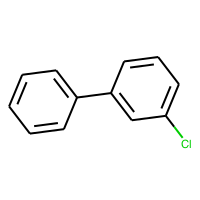

188.657

13

2

0.0

```python
#Read solubility data
sol_data = pd.read_csv('datasets/huuskonsen_data.csv')

#Add some new descriptors (physchem properties)
sol_data['ROMol'] = sol_data['smiles'].apply(Chem.MolFromSmiles)
print("The Huuskonsen solubility data set contains ", len(sol_data), " compounds")

# Adding a few more descriptors (MW, HAC, RingCount, and TPSA)
# Althought, in this project we will use only the structural fingerprints
# to calculate a small molecule's logp
sol_data['MW']             = sol_data['ROMol'].map(Descriptors.MolWt)
sol_data['HeavyAtomCount'] = sol_data['ROMol'].map(Descriptors.HeavyAtomCount)
sol_data['RingCount']      = sol_data['ROMol'].map(Descriptors.RingCount)
sol_data['TPSA']           = sol_data['ROMol'].map(Descriptors.TPSA)

# Add Chemical structure to Pandas frame
PandasTools.AddMoleculeColumnToFrame(sol_data,smilesCol='smiles',molCol='ROMol',includeFingerprints=True)

# Target values
y = sol_data['solubility'].values
sol_data.head(n=1)
```

1297 small organic compounds can be found in the Huuskonsen data set.  
Let's **visualize** the *chemical space* of the compounds found in the training dataset!

```python
sol_data.describe()
```

|  | solubility | logp | MW | HeavyAtomCount | RingCount | TPSA |
| --- | --- | --- | --- | --- | --- | --- |
| count | 1297.000000 | 1297.000000 | 1297.000000 | 1297.000000 | 1297.000000 | 1297.000000 |
| mean | -2.751434 | 2.443724 | 199.453295 | 13.045490 | 1.382421 | 36.640486 |
| std | 2.040823 | 2.036324 | 94.710410 | 6.299392 | 1.269393 | 34.777512 |
| min | -11.620000 | -8.780000 | 17.031000 | 1.000000 | 0.000000 | 0.000000 |
| 25% | -3.960000 | 1.280000 | 122.189000 | 8.000000 | 0.000000 | 9.230000 |
| 50% | -2.510000 | 2.340000 | 178.220000 | 12.000000 | 1.000000 | 29.100000 |
| 75% | -1.380000 | 3.590000 | 260.676000 | 17.000000 | 2.000000 | 52.930000 |
| max | 1.580000 | 10.200000 | 665.733000 | 47.000000 | 7.000000 | 331.940000 |

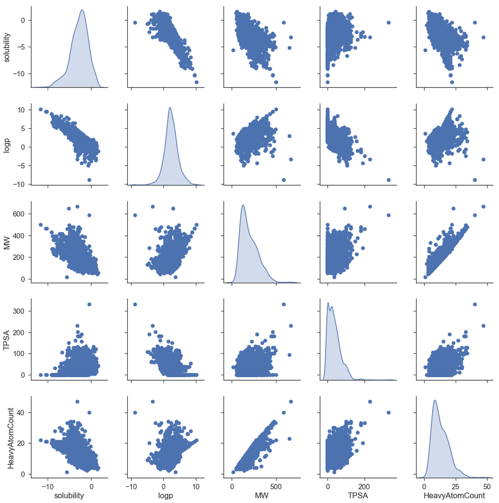

```python
# seaborn -- for better looking plots
import seaborn as sns
sns.set(style="ticks", color_codes=True)
sns.set_context("notebook", font_scale=1.5, rc={"lines.linewidth": 1.5})
#sns.set_context("talk", rc={"lines.linewidth": 2})
sns.color_palette("pastel")

g = sns.pairplot(sol_data[['solubility', 'logp', 'MW', 'TPSA', 'HeavyAtomCount']], size=3, diag_kind="kde", markers="o",
                 plot_kws=dict(s=50, edgecolor="b", linewidth=1),
                 diag_kws=dict(shade=True))
```

### Training dataset's description

From the plot and the data summary, displayed above, we notice that there are a few compounds with high MW (MW~600) and high Polar Surface Area (TPSA > 100). I would like to highlight these compounds and then it will be interesting to check how the models's behaviour on these compounds.

```
There are 15 compounds with high MW (>550) and TPSA (>130) values!
```

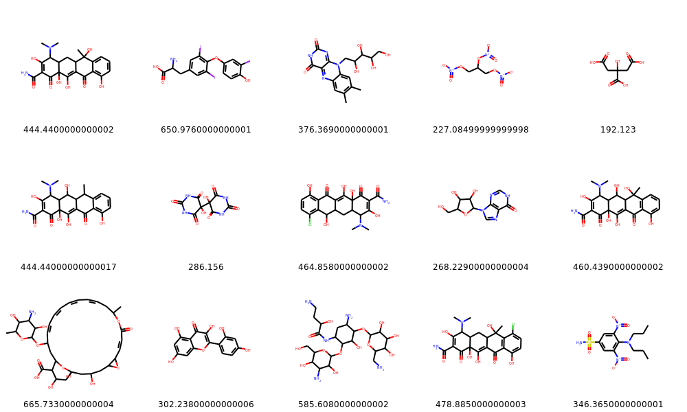

```python
highMW =  sol_data[(sol_data['MW'] > 550) | (sol_data['TPSA'] > 130)]
#highMW.head()
print("There are", len(highMW), "compounds with high MW (>550) and TPSA (>130) values!")
PandasTools.FrameToGridImage(highMW,molsPerRow=5, legendsCol='MW')
```

There are indeed some really "interesting" compounds in this dataset.

## Fingerprints

### Let's generate some (chemical) fingerprints!

We would like to encode the 2D structure of a molecule in a form that a machine learning model could "understand". In this work we will use the fingerprint approach.

Fingerprints were first used in molecular substructure search: finding a compound with a certain substructure in a molecular database. Fingerprinting creates an efficient representation of the molecular graph. The basic process of fingerprinting is as follows, first the algorithm generates a set of patterns. For instance, enumeration of different paths is common:

For example (taken from Daylight's site), the molecule OC=CN would generate the following patterns:  
0-bond paths: C / O / N  
1-bond paths: OC / C=C / CN  
2-bond paths: OC=C / C=CN  
3-bond paths: OC=CN

If the number of bits is reduced in amount we risk two different atom environments being encoded with the same bits. Thus two molecules could be identified as more similar than they actually are.

More info about chemical fingerprints can be found here [2].

RDKIT (rdkit.org), an open source cheminformatics library, is used for generating the fingerprints.

```python
print("Converting Estate fingerprints")

# Estate fingerprints
def estate_fingerprint(mol):
    return FingerprintMol(mol)[0]

sol_data['fp_Estate'] = sol_data['ROMol'].apply(estate_fingerprint)

print("Converting Morgan fingerprints")

# Morgan fingerprints, length 1024 bits
def Morgan_fingerprint(mol):
    fp = np.zeros((1,))
    ConvertToNumpyArray(GetMorganFingerprintAsBitVect(mol, 2, nBits = 1024), fp)
    return fp

sol_data['fp_Morgan'] = sol_data['ROMol'].apply(Morgan_fingerprint)

print("Converting RDKit fingerprints")

# RDKit fingerprints, length 1024 bits
def RDKit_fingerprint(mol):
    fp = np.zeros((1,))
    ConvertToNumpyArray(RDKFingerprint(mol, 2, fpSize = 1024), fp)
    return fp

sol_data['fp_RDKit'] = sol_data['ROMol'].apply(RDKit_fingerprint)

print("Converting Topological torsion fingerprints")

# Topological torsion (1987), length 1024 bits
def Torsion_fingerprint(mol):
    fp = np.zeros((1,))
    ConvertToNumpyArray(GetHashedTopologicalTorsionFingerprintAsBitVect(mol, nBits = 1024), fp)
    return fp

sol_data['fp_Torsion'] = sol_data['ROMol'].apply(RDKit_fingerprint)

print("Converting Extended reduced graph approach fingerprints")

# ErG (Extended reduced graph approach) fingerprints (2006)
# Create by researchers in Eli Lilly
# http://pubs.acs.org/doi/abs/10.1021/ci050457y
def ErG_fingerprint(mol):
    return GetErGFingerprint(mol)

sol_data['fp_ErG'] = sol_data['ROMol'].apply(ErG_fingerprint)

print ("Converting Avalon bit based fingerprints")

# Avalon bit based (2006), length 1024 bits
def Avalon_fingerprint(mol):
    fp = np.zeros((1,))
    ConvertToNumpyArray(GetAvalonFP(mol, nBits = 1024), fp)
    return fp

sol_data['fp_Avalon'] = sol_data['ROMol'].apply(Avalon_fingerprint)
```

```
Converting Estate fingerprints
Converting Morgan fingerprints
Converting RDKit fingerprints
Converting Topological torsion fingerprints
Converting Extended reduced graph approach fingerprints
Converting Avalon bit based fingerprints
```

### Fingerprint's performance

Comparison of the fingerprints generated previously, employing 20 fold cross validation (https://en.wikipedia.org/wiki/Cross-validation), and a Bayesian Ridge regression model (http://scikit-learn.org/stable/modules/linear_model.html#bayesian-ridge-regression).

```python
StS = StandardScaler()

fps = ['fp_Estate', 'fp_Morgan', 'fp_RDKit', 'fp_Torsion', 'fp_ErG', 'fp_Avalon']

def get_model_cv(model, x, y, cv=20):
    scores = cross_validation.cross_val_score(model, x, y, cv=cv, n_jobs=-1,
                                              scoring='neg_mean_absolute_error')
    return -1 * scores.mean()

def try_fps(fps, model, y, verbose = True):

    fps_score = {}

    for fp in fps:
        x = np.array(list(sol_data[fp]))
        #X = np.array(list(sol_data[fp]))
        #x = StS.fit_transform(X)
        if verbose: print("Generating %9s fingerprints" % (fp))
        fps_score[fp] = get_model_cv(model, x, y)

    fps_sorted = sorted(fps_score, key=fps_score.__getitem__, reverse=False)

    print("\n----------------------------------")
    print("   name          CV avg(|error|)")
    print("----------------------------------")
    for i in range(len(fps_sorted)):
        name = fps_sorted[i]
        print("%10s            %5.3f " % (name, fps_score[name]))
    print("----------------------------------")

# Tikhonov estimation
try_fps(fps, BayesianRidge(n_iter=300, tol=0.001, alpha_1=1e-03, alpha_2=1e-03, lambda_1=1e-03, lambda_2=1e-03), y, verbose=True)
#try_fps(fps, Ridge(alpha=1e-3), y, verbose=True)
```

```
Generating fp_Estate fingerprints
Generating fp_Morgan fingerprints
Generating  fp_RDKit fingerprints
Generating fp_Torsion fingerprints
Generating    fp_ErG fingerprints
Generating fp_Avalon fingerprints
----------------------------------
   name          CV avg(|error|)
----------------------------------
 fp_Estate            0.675
 fp_Avalon            0.765
  fp_RDKit            0.795
fp_Torsion            0.795
 fp_Morgan            0.859
    fp_ErG            1.280
----------------------------------
```

I will use the Estate fingerprint, as they result the lowest mean absolute error regression loss. A new data matrix *X* is created and then fed into machine learning models.

```python
X = np.array(list(sol_data['fp_Estate']))
```

### ML Gym area

Applying grid search to explore the hyperparameters of the RandomForestRegressor, LightGBMRegressor, GaussianProcessRegressor, and Kernel Ridge models in sklearn.

```python
RFmodel = GridSearchCV(RandomForestRegressor(), cv=20,
                       param_grid={"n_estimators": np.linspace(50, 150, 25).astype('int')},
                       scoring='neg_mean_absolute_error', n_jobs=-1)

RFmodel = RFmodel.fit(X, y)
Best_RandomForestRegressor = RFmodel.best_estimator_

print("Best Random Forest model")
print('Best parameters found by grid search are:', RFmodel.best_params_)
print('Best score:', -1*RFmodel.best_score_)
```

[output not shown]

```python
param_grid = {
    'learning_rate': [0.01, 0.1, 1],
    'n_estimators': [20, 40]
}

GBMmodel = GridSearchCV(lgb.LGBMRegressor(num_leaves=31), param_grid,
                        scoring='neg_mean_absolute_error', n_jobs=-1)

GBMmodel.fit(X, y)
Best_GBMRegressor = GBMmodel.best_estimator_

print("Best high performance Gradient Boosting model")
print('Best parameters found by grid search are:', GBMmodel.best_params_)
print('Best score:', -1*GBMmodel.best_score_)
```

```
Best high performance Gradient Boosting model
Best parameters found by grid search are: {'learning_rate': 0.1, 'n_estimators': 40}
Best score: 0.6715742099308762
```

```python
GPmodel = GridSearchCV(GaussianProcessRegressor(normalize_y=True), cv=20,
                       param_grid={"alpha": np.logspace(-15, -10, 30),}, scoring='neg_mean_absolute_error', n_jobs=-1)

GPmodel = GPmodel.fit(X, y)
Best_GaussianProcessRegressor = GPmodel.best_estimator_

print("Best Gaussian Process model")
print('Best parameters found by grid search are:', GPmodel.best_params_)
print('Best score:', -1*GPmodel.best_score_)
```

```
Best Gaussian Process model
Best parameters found by grid search are: {'alpha': 1.0826367338740562e-14}
Best score: 0.7379553682433945
```

```python
KRmodel = GridSearchCV(KernelRidge(), cv=10,
                       param_grid={"alpha": np.logspace(-10, -5, 10),
                       "gamma": np.logspace(-12, -9, 10), "kernel" : ['laplacian', 'rbf']}, scoring='neg_mean_absolute_error', n_jobs=-1)

KRmodel = KRmodel.fit(X, y)
Best_KernelRidge = KRmodel.best_estimator_

print("Best Kernel Ridge model")
print('Best parameters found by grid search are:', KRmodel.best_params_)
print('Best score for Kernel Ridge model: ', -1*KRmodel.best_score_)
```

```
Best Kernel Ridge model
Best parameters found by grid search are: {'alpha': 1e-10, 'gamma': 4.641588833612773e-11, 'kernel': 'laplacian'}
Best score for Kernel Ridge model:  0.6647051263131264
```

## Machine Learning models

*Linear regression* will be used as benchmark model and the following machine learning models will be tested:

```python
alpha_grid = {'alpha': np.logspace(1e-11,1e-1,8)}

ml_models = {
            'Linear Regression': LinearRegression(),
            'Kernel Ridge Regression': Best_KernelRidge,
            'Guassian Process Regressor': Best_GaussianProcessRegressor,
            'Support Vector Regression': SVR(),
            'KNeighborsRegressor': KNeighborsRegressor(),
            'Neural Network': MLPRegressor(alpha=100,max_iter=8000, hidden_layer_sizes=[8,6], early_stopping=False),
            'Gradient Boosted Trees': GradientBoostingRegressor(n_estimators=100),
            'Random forest': Best_RandomForestRegressor,
            'LightGBM': Best_GBMRegressor,
            'XGBoost': XGBRegressor(n_estimators=100, learning_rate=0.08, gamma=0, subsample=0.75,
                                    colsample_bytree=1, max_depth=7)
            }
```

The following plotting function will be employed to visualize the performance of the machine learning models.

```python
import matplotlib.pyplot as plt
%matplotlib inline

def plot_results(y_pred_train, y_pred_test, y_train, y_test, title='', figsize=(6,4), fontsize=16):
    plt.clf()
    plt.figure(figsize=figsize)
    plt.scatter(y_train,y_pred_train, label = 'Train', c='blue')
    plt.title(title,fontsize=fontsize+1)
    plt.xlabel('Experimental Solubility (mol/L)', fontsize=fontsize)
    plt.ylabel('Predicted Solubility (mol/L)', fontsize=fontsize)
    plt.scatter(y_test,y_pred_test,c='lightgreen', label='Test', alpha = 0.8)
    plt.legend(loc=4)
    plt.show()
```

### Let's do some ML!

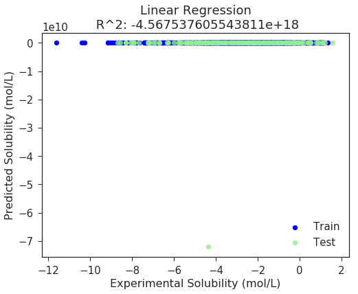

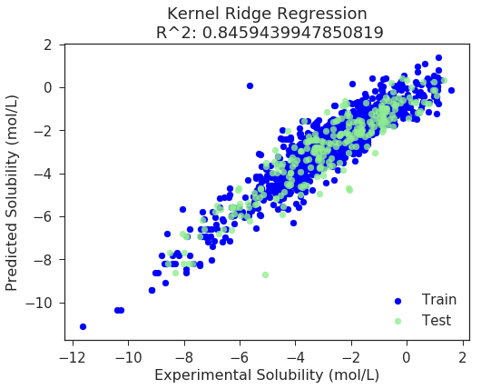

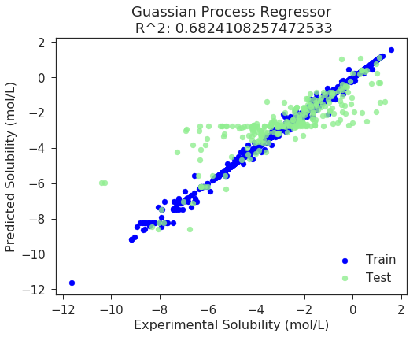

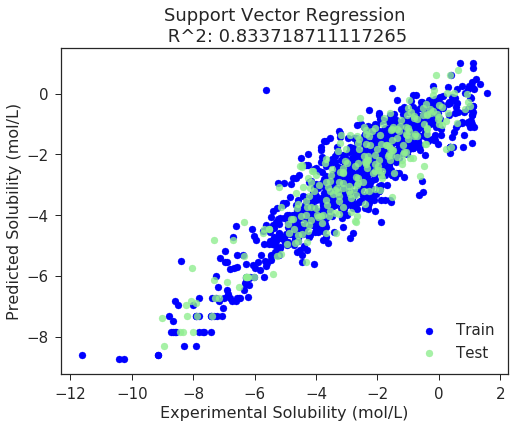

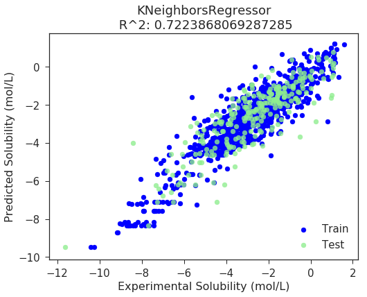

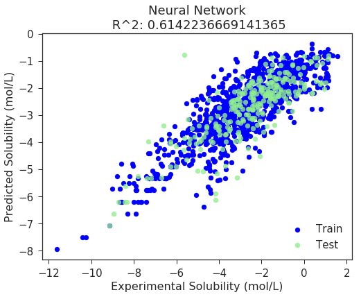

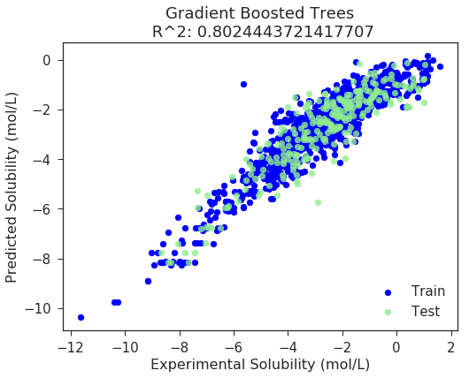

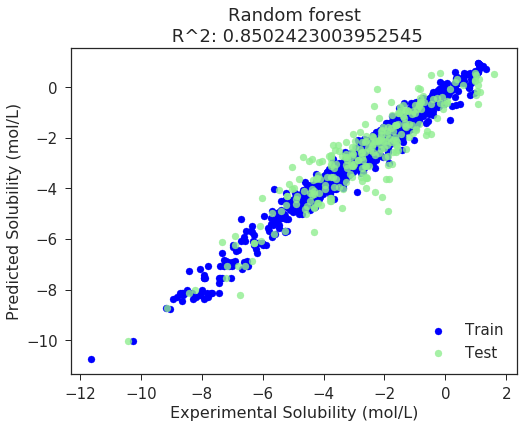

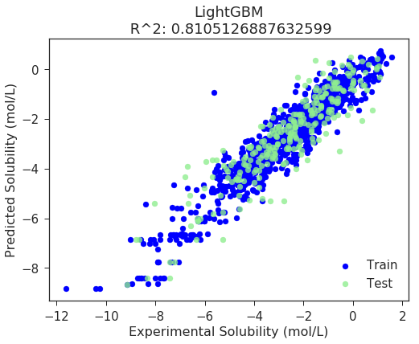

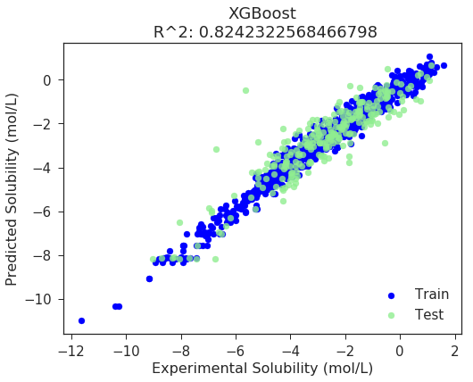

```
----------------------------------
           ML model     &   R^2   & RMSe  & Spearman R coefficient  & Explained variance score  &   % test err   & abs error in CV
----------------------------------
            Random forest  0.850  0.758  0.900  0.850  81.441   0.570
  Kernel Ridge Regression  0.846  0.848  0.910  0.846  51.513   0.661
Support Vector Regression  0.834  0.877  0.891  0.836  96.977   0.653
                  XGBoost  0.824  0.811  0.893  0.825  52.393   0.548
                 LightGBM  0.811  0.874  0.903  0.811  88.546   0.619
   Gradient Boosted Trees  0.802  0.880  0.872  0.804  41.889   0.693
      KNeighborsRegressor  0.722  1.045  0.832  0.728  61.250   0.714
Guassian Process Regressor  0.682  1.199  0.866  0.691  40.659   0.738
           Neural Network  0.614  1.210  0.788  0.619  41.504   1.016
        Linear Regression  -4567537605543811072.000  4465895727.632  0.866  -4549970153219920896.000  85.603   2640621068.475
----------------------------------
```

```python
mean_scores = {}
percent_errors = {}
rmses = {}
r_squares = {}
spearmanRs = {}
evss = {}

for (name, model) in ml_models.items():
    #print("Running %s ..." % name)
    scores = cross_validation.cross_val_score(model, X, y, cv=20, n_jobs=-1, scoring='neg_mean_absolute_error')
    scores = -1*scores
    mean_score = scores.mean()
    mean_scores[name] = mean_score

    X_train, X_test, y_train, y_test = cross_validation.train_test_split(X, y, test_size=0.2)

    model.fit(X_train, y_train)

    y_pred_train = model.predict(X_train)
    y_pred_test  = model.predict(X_test)

    #print("Calculating % and rms error, R^2 and Spearman coefficient")

    # % error
    percent_error = np.mean( 100 * np.abs(y_test - y_pred_test) / np.abs(y_pred_test))
    percent_errors[name] = percent_error

    # Root Mean Square error
    rmse = mean_squared_error(y_test, y_pred_test) ** 0.5
    rmses[name] = rmse

    # R^2
    r_square = r2_score(y_test, y_pred_test)
    r_squares[name] = r_square

    # Spearman of prediction
    spr = spearmanr(y_test, y_pred_test)
    spearmanRs[name] = spr[0]

    # explained_variance_score
    evs = explained_variance_score(y_test, y_pred_test)
    evss[name] = evs

    # Call ploting function
    fulltitle = name + '\n R^2: ' + str(r_square)
    plot_results(y_pred_train, y_pred_test, y_train, y_test, title=fulltitle, figsize = (8,6))

# Sorting models dictionary based on R square
sorted_names = sorted(r_squares, key=r_squares.__getitem__, reverse=True)

print("\n----------------------------------")
print("           ML model     &   R^2   & RMSe  & Spearman R coefficient  & Explained variance score  &   % test err   & abs error in CV")
print("----------------------------------")
for i in range(len(sorted_names)):
    name = sorted_names[i]
    print("%25s  %5.3f  %5.3f  %5.3f  %5.3f  %5.3f   %5.3f " % (name, r_squares[name], rmses[name], spearmanRs[name], evss[name], percent_errors[name], mean_scores[name]))

print("----------------------------------")
```

### Results and Discussion

| **ML model** | **R^2** | **RMSe** | **Spearman R coefficient** | **Explained variance score** | **% test err** | **abs error in CV** |
| --- | --- | --- | --- | --- | --- | --- |
| Random forest | 0.85 | 0.758 | 0.9 | 0.85 | 81.441 | 0.57 |
| Kernel Ridge Regression | 0.846 | 0.848 | 0.91 | 0.846 | 51.513 | 0.661 |
| Support Vector Regression | 0.834 | 0.877 | 0.891 | 0.836 | 96.977 | 0.653 |
| XGBoost | 0.824 | 0.811 | 0.893 | 0.825 | 52.393 | 0.548 |
| LightGBM | 0.811 | 0.874 | 0.903 | 0.811 | 88.546 | 0.619 |
| Gradient Boosted Trees | 0.802 | 0.88 | 0.872 | 0.804 | 41.889 | 0.693 |
| KNeighborsRegressor | 0.722 | 1.045 | 0.832 | 0.728 | 61.25 | 0.714 |
| Guassian Process Regressor | 0.682 | 1.199 | 0.866 | 0.691 | 40.659 | 0.738 |
| Neural Network | 0.614 | 1.21 | 0.788 | 0.619 | 41.504 | 1.016 |
| Linear Regression | -4.56754E+18 | 4465895728 | 0.866 | -4.54997E+18 | 85.603 | 2640621068 |

Random forest is the best performing model for predicting aqueous solublity with an $R^2$ value of 0.85 and the smallest root mean squared error (rmse). Random forest have been used widely in chemoinformatics and they are quite established in the field. Kernel Ridge regression, Support Vector Regression, XGBoost, Gradient Boosted tree, and LightGBM follow very closely with high $R^2$ values and very similar rmse values.

I find very interesting the fact that linear regression performs very poorly in this case. Possibly, the use of fingerprints as descriptors is the cause of this low performance.

### Conclusions

The predictability of several machine learning models have been tested in infering the aqueous solubility of small organic compounds. Random forest model performed slightly better than the other machine learning models. In future work I will try to examine how Deep learning models with different architectures perform in this problem.

### References

1. https://pubs.acs.org/doi/abs/10.1021/ci9901338
2. http://www.daylight.com/dayhtml/doc/theory/theory.finger.html
3. QSAR Comb. Sci., 2004, 23, 311-218